# Lab 4: Decision Trees — Reading One, and Finding Where It Breaks

ECON 8310: Business Forecasting — University of Nebraska at Omaha

# What we are doing

Today the course changes character. Everything so far specified a structure and estimated it. A tree is handed a pile of features and finds the structure itself.

We use **the same series you just forecast in Homework 2** — daily units for CA_1 FOODS. Same store, same aisle, same target. Last week you fitted a GAM to it. Today you fit a tree, and the comparison is the point: you will be able to say what each method bought you on identical data.

By the end you will have done four things: read a fitted tree out loud, watched the bias–variance tradeoff happen in a table, discovered why a single tree is unstable, and found the one place trees reliably fail.

**Suggested time:** ~40 minutes · **You will need:** `pandas`, `numpy`, `matplotlib`, `scikit-learn`, and `data/processed/m5_daily.csv` (run `python scripts/prep_m5.py` if it is missing).

# Setup

```python
import pandas as pd
import numpy as np
import matplotlib.pyplot as plt
from sklearn.tree import DecisionTreeRegressor, export_text, plot_tree
import warnings
warnings.filterwarnings('ignore')

from pathlib import Path

def data_path(name):
    """Find the processed data file whether you render from the repo root or from
    this file's own folder."""
    for base in (Path.cwd(), *Path.cwd().parents):
        p = base / "data" / "processed" / name
        if p.exists():
            return p
    raise FileNotFoundError(
        f"Could not find data/processed/{name}. "
        "Run `python scripts/prep_m5.py` from the repository root first."
    )

RANDOM_STATE = 42

daily = pd.read_csv(data_path("m5_daily.csv"), parse_dates=["date"])
daily["dow"] = daily["date"].dt.dayofweek        # 0 = Monday
daily["doy"] = daily["date"].dt.dayofyear

FEATURES = ["units_lag1", "units_lag7", "units_lag14", "units_lag28", "units_lag365",
            "snap", "is_event", "dow", "doy", "avg_price"]

df = daily.dropna(subset=FEATURES).copy()

N_TEST = 365
train, test = df.iloc[:-N_TEST], df.iloc[-N_TEST:]
X_train, y_train = train[FEATURES].values, train["units"].values
X_test,  y_test  = test[FEATURES].values,  test["units"].values

rmse = lambda a, b: float(np.sqrt(np.mean((np.asarray(a) - np.asarray(b)) ** 2)))

print(f"{len(df)} usable days — train {len(train)}, test {len(test)}")
print(f"benchmark (same day last year): RMSE {rmse(y_test, test.units_lag365.values):,.0f}")
```

```
1576 usable days — train 1211, test 365
benchmark (same day last year): RMSE 625
```

**Notice what just happened to the data.** There is no date index in `X_train`. Every row is an independent example, and everything the model knows about time is sitting in the lag columns. That reframing — a time series becomes a flat table — is what lets every method from here to Lecture 9 be applied to forecasting at all.

# Step 1 — Fit a tree and read it out loud

Start deliberately shallow, because a depth-3 tree is small enough to read.

```python
tree3 = DecisionTreeRegressor(max_depth=3, random_state=RANDOM_STATE).fit(X_train, y_train)

print(export_text(tree3, feature_names=FEATURES, decimals=0))
print(f"\ntest RMSE: {rmse(y_test, tree3.predict(X_test)):,.0f}")
```

```
|--- dow <= 4
|   |--- units_lag28 <= 2596
|   |   |--- units_lag1 <= 2378
|   |   |   |--- value: [2210]
|   |   |--- units_lag1 >  2378
|   |   |   |--- value: [2511]
|   |--- units_lag28 >  2596
|   |   |--- units_lag7 <= 2544
|   |   |   |--- value: [2602]
|   |   |--- units_lag7 >  2544
|   |   |   |--- value: [2951]
|--- dow >  4
|   |--- units_lag1 <= 3351
|   |   |--- units_lag1 <= 2510
|   |   |   |--- value: [3049]
|   |   |--- units_lag1 >  2510
|   |   |   |--- value: [3638]
|   |--- units_lag1 >  3351
|   |   |--- is_event <= 0
|   |   |   |--- value: [4041]
|   |   |--- is_event >  0
|   |   |   |--- value: [3583]


test RMSE: 337
```

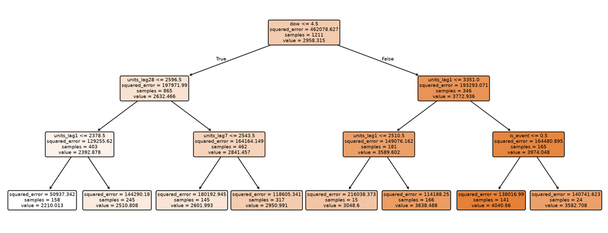

```python
fig, ax = plt.subplots(figsize=(13, 5))
plot_tree(tree3, feature_names=FEATURES, filled=True, rounded=True, fontsize=7, ax=ax)
plt.tight_layout()
```

**Put the root split into business language** — not `dow <= 4.50` but what that *means* about this store.

*In the room:* read it aloud to the person next to you. Saying it to someone is what exposes a sentence you do not actually understand.  
*On your own:* write the sentence in a comment, then add a prediction you can check immediately:

```
# the root split separates ____ from ____
# I expect the higher-sales side to be dow <= 4.50 / dow > 4.50, because ____
```

Then read the two node values off the tree plot above and see whether you were right. A guess you wrote down and checked teaches you more than a split you merely read.

Then look at the importances:

```python
imp = pd.Series(tree3.feature_importances_, index=FEATURES).sort_values(ascending=False)
print(imp[imp > 0].round(3).to_string())
```

```
dow            0.789
units_lag28    0.106
units_lag1     0.064
units_lag7     0.030
is_event       0.011
```

**Compare this with the lecture slide**

Lecture 4’s importance table was computed on **weekly** CA_1 FOODS, and there the four-week lag dominated. Here, on **daily** data for the same store and aisle, something else wins outright.

Same store. Same product. Different frequency, different answer. Say why before moving on.

# Step 2 — Watch the bias–variance tradeoff happen

Lecture 4 drew this as a curve. Now produce it.

```python
rows = []
for depth in [1, 2, 3, 5, 8, 12, None]:
    t = DecisionTreeRegressor(max_depth=depth, random_state=RANDOM_STATE).fit(X_train, y_train)
    rows.append({"depth": str(depth),
                 "leaves": t.get_n_leaves(),
                 "train_RMSE": round(rmse(y_train, t.predict(X_train))),
                 "test_RMSE":  round(rmse(y_test,  t.predict(X_test)))})

sweep = pd.DataFrame(rows)
print(sweep.to_string(index=False))
```

```
depth  leaves  train_RMSE  test_RMSE
    1       2         443        413
    2       4         388        369
    3       8         354        337
    5      32         284        303
    8     179         184        313
   12     698          84        385
 None    1200           0        406
```

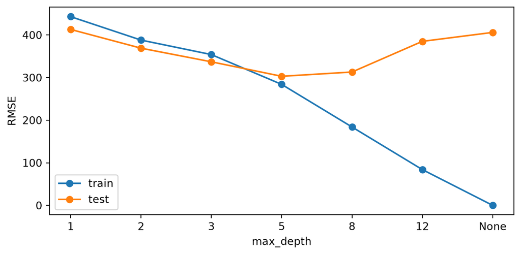

```python
fig, ax = plt.subplots(figsize=(7, 3.5))
ax.plot(range(len(sweep)), sweep.train_RMSE, marker="o", label="train")
ax.plot(range(len(sweep)), sweep.test_RMSE,  marker="o", label="test")
ax.set_xticks(range(len(sweep))); ax.set_xticklabels(sweep.depth)
ax.set_xlabel("max_depth"); ax.set_ylabel("RMSE"); ax.legend()
plt.tight_layout()
```

**Two things to say out loud.** What does the training error do as depth increases, and what number does it reach at the end? And where does the *test* error bottom out?

The gap between those two curves is overfitting, drawn to scale.

# Step 3 — Why one tree is not enough

Lecture 4 claimed a tree is unstable: change the data slightly and the structure changes. Test it properly, using bootstrap resamples — draw a sample of the same size *with replacement*, refit, and repeat.

```python
rng = np.random.RandomState(RANDOM_STATE)
roots, preds = {}, []

for b in range(20):
    idx = rng.choice(len(X_train), len(X_train), replace=True)
    t = DecisionTreeRegressor(max_depth=5, random_state=RANDOM_STATE).fit(X_train[idx], y_train[idx])
    root = [l.strip() for l in export_text(t, feature_names=FEATURES).split("\n")
            if l.startswith("|---")][0]
    roots[root] = roots.get(root, 0) + 1
    preds.append(t.predict(X_test))

P = np.array(preds)
print("root splits across 20 bootstrap trees:")
for k, v in sorted(roots.items(), key=lambda kv: -kv[1]):
    print(f"  {v:2d} x  {k}")
print(f"\nper-day spread of predictions across the 20 trees:")
print(f"  average sd {P.std(0).mean():,.0f} units   worst day {P.std(0).max():,.0f} units")
```

```
root splits across 20 bootstrap trees:
  20 x  |--- dow <= 4.50

per-day spread of predictions across the 20 trees:
  average sd 160 units   worst day 1,137 units
```

The root may well be stable — one feature can be dominant enough that every resample finds it first. **That is not the same as the tree being stable.** Look at the spread of predictions: on a typical day the twenty trees disagree by a meaningful margin, and on the worst day they disagree enormously. All that disagreement lives *below* the root.

Now the payoff, and it is one line:

```python
single = np.mean([rmse(y_test, p) for p in P])
averaged = rmse(y_test, P.mean(0))

print(f"average RMSE of a single bootstrap tree : {single:,.0f}")
print(f"RMSE of the 20 trees averaged together  : {averaged:,.0f}")
print(f"improvement: {100*(single-averaged)/single:.0f}%")
```

```
average RMSE of a single bootstrap tree : 324
RMSE of the 20 trees averaged together  : 266
improvement: 18%
```

You just built a **bagged ensemble** by hand — bootstrap aggregating, in three lines. Nothing was tuned and no new information was added; the gain came entirely from averaging away the disagreement you measured above. It is not yet a Random Forest: a forest adds one more idea, which is to stop every tree from looking at `dow` first. Twenty trees that agree perfectly on their root are twenty trees making correlated mistakes. That is next week.

# Step 4 — Where trees reliably fail

A tree predicts the **mean of the training rows in a leaf**. So every prediction it can ever make is an average of values it has already seen.

```python
full = DecisionTreeRegressor(random_state=RANDOM_STATE).fit(X_train, y_train)
p = full.predict(X_test)

print(f"training target range : [{y_train.min():,.0f}, {y_train.max():,.0f}]")
print(f"prediction range      : [{p.min():,.0f}, {p.max():,.0f}]")
```

```
training target range : [0, 5,016]
prediction range      : [0, 4,527]
```

The predictions cannot leave the training range — not “usually do not,” *cannot*. Now watch what that does at the extremes.

```python
hi = y_test > np.percentile(y_test, 90)
lo = y_test < np.percentile(y_test, 10)

print(f"busiest 10% of test days  (n={hi.sum()}): actual {y_test[hi].mean():,.0f}"
      f"   predicted {p[hi].mean():,.0f}   under by {y_test[hi].mean()-p[hi].mean():,.0f}")
print(f"quietest 10% of test days (n={lo.sum()}): actual {y_test[lo].mean():,.0f}"
      f"   predicted {p[lo].mean():,.0f}   over by  {p[lo].mean()-y_test[lo].mean():,.0f}")
```

```
busiest 10% of test days  (n=37): actual 4,115   predicted 3,929   under by 186
quietest 10% of test days (n=37): actual 2,030   predicted 2,237   over by  207
```

**Your turn:** the two errors above point in opposite directions. Plot predicted against actual for the test set, add the 45-degree line, and see the shape this produces.

```python
# ---- your turn: uncomment and fill in the two blanks ----
# fig, ax = plt.subplots(figsize=(4.5, 4.5))
# ax.scatter(___, ___, s=6, alpha=0.4)          # <- actual on x, predicted on y
# lims = [y_test.min(), y_test.max()]
# ax.plot(lims, lims, "k--", lw=1)
# ax.set_xlabel("actual units"); ax.set_ylabel("predicted units")
# plt.tight_layout()
```

# Before you leave

You should have found that the tree systematically under-predicts the busiest days and over-predicts the quietest ones, and that averaging twenty unstable trees beat any one of them.

> **Discuss (the failure):** A tree pulls its predictions toward the middle at both ends. Give the mechanical reason — think about what a leaf prediction actually is.

> Then the operational version: this store is planning inventory. Which of those two errors costs more, and does your answer change if the product is milk rather than canned goods?

> **Discuss (the comparison):** You forecast this exact series with a GAM last week. Which method would you rather hand to a store manager, and what specifically would each one let you say that the other would not?

*Solutions posted to Canvas after class.*